# Unsupervised Learning - Project 7: AllLife Bank Customer Segmentation

### Submission Due Date: Sep 25, 2021

### Project Name: AllLife Bank Customer Segmentation

### Course Group: Group H - PGP-DSBA-UT 2021

### Student Name: James Moralez, P.E.

### Project Version: 1, submitted 25 Sep 2021

# Objective:

To identify different segments within the existing **AllLife Bank** customer base, based on their spending patterns as well as past interaction with the bank, using clustering algorithms, and provide recommendations to the bank on how to better market to and service these customers.

Provide the statistical analysis to complete the following tasks:

1. Explore and visualize the dataset to identify different segments of the customer base
2. Apply the clustering algorithms to discover hidden or interesting patterns in unlabeled data
3. As needed, apply dimensionality reduction techniques to reduce the dimension of data
4. Generate a set of insights and recommendations that will help the bank to better market to and service these customers

# Key Questions

- How many different groups/clusters can be found from the data?
- How do these different groups differ from each other?
- Do you get slightly different solutions from two different techniques? How would you explain the difference?
- Which variables should be used for clustering?

# Data Dictionary:

**Credit Card Customer Data.xlsx** - The Excel file contains the customer base for **AllLife Bank** that includes the customer profile and personal information in regard to customer accounts, and contains the following fields:

- **l_No:** Primary key of the records
- **Customer Key:** Customer identification number
- **Average Credit Limit:** Average credit limit of each customer for all credit cards
- **Total credit cards:** Total number of credit cards possessed by the customer
- **Total visits bank:** Total number of Visits that customer made (yearly) personally to the bank
- **Total visits online:** Total number of visits or online logins made by the customer (yearly)
- **Total calls made:** Total number of calls made by the customer to the bank or its customer service department (yearly)

# Notes:

- Coding sources or origin of learning identified through the use of an abbreviation of when the syntax or function was learned or the idea for using it is from, example: UL-W2-2.6 - Unsupervised Learning, Week 2, Section 2.6 or UL-W1-MLS 1, etc.
- To provide easier reading (present or future), testing, troubleshooting, and coding flow, some functions have been combined together within the same cell. Comments though should provide adequate description of the objective of the cell.
- Use of \t tabs output to provide cleaner visual alignment and \n to create line space instead of print(' ')

# Import and Loading Library Packages

### Import and Loading Library Packages

```python
# Import necessary and important packages and Libraries to help with reading and manipulating data
import os                                        # os package in case os functions are required - PF-W1-1.12
import numpy as np                               # For its data frame operations
import scipy                                     # For numerical routines and statistics functions
import pandas as pd                              # Pandas library used for data manipulation and analysis
# import pandas_profiling                        # Needed for running Pandas Profiling Report
# from pandas_profiling import ProfileReport

# Libraries to help with data visualization
import seaborn as sns                            # for visualisations (use semi-colon ; when using sns.)
sns.set(color_codes=True)                        # True-adds background to the graphs and plots, else blank
sns.set_style("darkgrid")                        # Set parameter style to 'darkgrid'

# To enable plotting graphs in Jupyter notebook
import matplotlib.pyplot as plt                  # seaborn based matplotlib library for plots/visualisations
%matplotlib inline
                                                 # "%" Python to display seaborn graphs inJupyter notebook
# Python warning filter
import warnings                                  # Must import 'warnings' to define filter in next line
warnings.filterwarnings("ignore")                # Filters out python "Pink" programming warning messages

# Importing scipy and sklearn statistical functions
from scipy.spatial.distance import cdist, pdist  # to compute distances
import scipy.stats as stats                      # for probability distributions and statistical functions
from scipy.stats import zscore                   # for using z-score
from sklearn.preprocessing import StandardScaler # to scale the data using z-score
from sklearn.cluster import (KMeans,)            # to perform k-means clustering and compute silhouette scores
from sklearn.metrics import (silhouette_score,)  # to compute the mean Silhouette Coefficient of all samples

# to perform hierarchical clustering, compute cophenetic correlation,  create dendrograms
from sklearn.cluster import AgglomerativeClustering
from scipy.cluster.hierarchy import dendrogram, linkage, cophenet

# to visualize the elbow curve and silhouette scores
from yellowbrick.cluster import KElbowVisualizer, SilhouetteVisualizer

# Removes the limit from the number of displayed columns and rows. - SL-W2-2.2
# To see the entire dataframe set display to "None"
pd.set_option("display.max_columns", None)       # None displays all columns
pd.set_option("display.max_rows", 200)           # default=200, None displays all columns

# Normally this cell provides no feedback or output, unless there is an error
# The following code has been addded to provide coder feedback that the cell ran properly
print("Import load complete")  # Indicator when cell finsihed running
print("numpy version:\t", np.__version__)        # Checks numpy version
print("pandas version:\t", pd.__version__)       # Checks pandas version
print("seaborn version:", sns.__version__)       # Checks seaborn version
print("scipy version:", scipy.__version__)       # Checks scipy verion
# print ('\n',os.getcwd())                       # to display working directory path/name if needed
```

```
Import load complete
numpy version:	 1.19.5
pandas version:	 1.3.1
seaborn version: 0.11.2
scipy version: 1.7.1
```

# Load and Overview of the Dataset

### Loading in the Excel File Dataset, Copy to Second Dataset, Display Dataset Head

```python
# Loading in the dataset
# Read the Dataset, Copy to Second Dataset, Display Dataset Head
data = pd.read_excel("Credit Card Customer Data.xlsx")             # Dataset loading from a Excel file
df = data.copy()                                                   # Copying dataset to df dataframe

# following function use to verify Excel load/copy ran properly
print(f"There are {df.shape[0]} rows and {df.shape[1]} columns.")  # f-string - SL-W2-2.2
display(df.head())                                                 # Display first 5 rows of data
display(df.dtypes.value_counts())                                  # display value counts of data types
```

```
There are 660 rows and 7 columns.
```

|  | Sl_No | Customer Key | Avg_Credit_Limit | Total_Credit_Cards | Total_visits_bank | Total_visits_online | Total_calls_made |
| --- | --- | --- | --- | --- | --- | --- | --- |
| 0 | 1 | 87073 | 100000 | 2 | 1 | 1 | 0 |
| 1 | 2 | 38414 | 50000 | 3 | 0 | 10 | 9 |
| 2 | 3 | 17341 | 50000 | 7 | 1 | 3 | 4 |
| 3 | 4 | 40496 | 30000 | 5 | 1 | 1 | 4 |
| 4 | 5 | 47437 | 100000 | 6 | 0 | 12 | 3 |

```
int64    7
dtype: int64
```

#### Displaying detailed info of each column attribute within the dataset

```python
df.info()  # Provides detailed info of each column attribute
```

```
<class 'pandas.core.frame.DataFrame'>
RangeIndex: 660 entries, 0 to 659
Data columns (total 7 columns):
 #   Column               Non-Null Count  Dtype
---  ------               --------------  -----
 0   Sl_No                660 non-null    int64
 1   Customer Key         660 non-null    int64
 2   Avg_Credit_Limit     660 non-null    int64
 3   Total_Credit_Cards   660 non-null    int64
 4   Total_visits_bank    660 non-null    int64
 5   Total_visits_online  660 non-null    int64
 6   Total_calls_made     660 non-null    int64
dtypes: int64(7)
memory usage: 36.2 KB
```

7 numerical integer attributes, with 660 observations, and no apparent missing data

#### Checking for Missing Data within Dataset

```python
# Checking for Missing Data within Dataset
# Verifying if the data has any missing entries before evaluating - Source MLS 4 Case Study
# isna() function should return in ascending order zeros if there is no missing data
print(df.isnull().sum().sort_values(ascending=False))
```

```
Sl_No                  0
Customer Key           0
Avg_Credit_Limit       0
Total_Credit_Cards     0
Total_visits_bank      0
Total_visits_online    0
Total_calls_made       0
dtype: int64
```

Dataset does not indicate any missing or NaN values

#### Check for zero (missing) assigned credit limits

```python
# check the attribute for any 0 limits
df[(df.Avg_Credit_Limit == 0)]
```

|  | Sl_No | Customer Key | Avg_Credit_Limit | Total_Credit_Cards | Total_visits_bank | Total_visits_online | Total_calls_made |
| --- | --- | --- | --- | --- | --- | --- | --- |

All customers have a Credit Limit assigned to them

### Duplicate Observations Check of the Dataset

```python
# searching and counting the number of duplicate records within the dataset
df.duplicated().sum()
```

```
0
```

Dataset does not indicate any duplicate observations within the dataset

### Brief evaluuation of Sl_No attribute to determine if needed

Typically, record ID's are unique to each customer record, therefore provide no analytical value and can be immediately be dropped from the dataset

#### Counting the number of Duplicate Values within the Sl_No column

```python
# Finding the Count of Duplicate Values in a Specific Column
df.duplicated(subset="Sl_No").sum()
```

```
0
```

No duplicate entries within the Sl_No column

#### Searching the number of unique entries within the Sl_No column

```python
# findiing the number of unique entries within a single attribute
df.Sl_No.nunique()
```

```
660
```

All 660 Sl_No column entries are unique

**Initial Observations and Insights of Dataset**

- The dataset contains 660 Observations and 7 Attributes
- All columns within the dataset are 'int64' data types
- The dataset does not contain duplicate Observations within it.
- The dataset does not indicate any missing values
- The **Customer Key** label contains an space that should be converted to an underscore "_"

*Sl_No Attribute*

- Has been verified to containing only unique entries for each observation
- Will not provide value to any sort of analysis
- Will be immediately removed from the dataset

#### Removal of Sl_No attribute from the dataset

```python
# Dropping the Sl_No attribute from the dataset
df.drop(["Sl_No"], axis=1, inplace=True)  # Drops the attribute column from the dataframe
```

The dataset now contains 660 rows and 6 columns

### Generate Descriptive Statistics

#### Use the Describe function to generate descriptive statistics that summarize the central tendency of the numerical attributes

```python
# generate descriptive statistics that summarize the central tendency,
# dispersion and shape of the dataset’s distribution
round(df.describe().T, 2)                # descriptive summary of dataset
```

|  | count | mean | std | min | 25% | 50% | 75% | max |
| --- | --- | --- | --- | --- | --- | --- | --- | --- |
| Customer Key | 660.0 | 55141.44 | 25627.77 | 11265.0 | 33825.25 | 53874.5 | 77202.5 | 99843.0 |
| Avg_Credit_Limit | 660.0 | 34574.24 | 37625.49 | 3000.0 | 10000.00 | 18000.0 | 48000.0 | 200000.0 |
| Total_Credit_Cards | 660.0 | 4.71 | 2.17 | 1.0 | 3.00 | 5.0 | 6.0 | 10.0 |
| Total_visits_bank | 660.0 | 2.40 | 1.63 | 0.0 | 1.00 | 2.0 | 4.0 | 5.0 |
| Total_visits_online | 660.0 | 2.61 | 2.94 | 0.0 | 1.00 | 2.0 | 4.0 | 15.0 |
| Total_calls_made | 660.0 | 3.58 | 2.87 | 0.0 | 1.00 | 3.0 | 5.0 | 10.0 |

**Observations and Insights**

- Attributes **Customer Key** and **Avg_Credit_Limit** appear as continuous type numerical data
- All other attributes appear to be categorical type data

## Unique Values within the Dataset Attributes

#### Checking the overall number of unique values in each attribute

```python
# outputting the overall number of unique values in each attribute
print(df.nunique().sort_values(ascending=False))
```

```
Customer Key           655
Avg_Credit_Limit       110
Total_visits_online     16
Total_calls_made        11
Total_Credit_Cards      10
Total_visits_bank        6
dtype: int64
```

**Observations**

Next we will create an attribute list

#### Creating an dataset attribute list

Since all of the attributes are of the int64 data type, we will use the data type as the arguement for creating the list for any future use

```python
# create a dataset attribute list
int_cols = df.select_dtypes(["int64"])
int_cols.columns
```

```
Index(['Customer Key', 'Avg_Credit_Limit', 'Total_Credit_Cards',
       'Total_visits_bank', 'Total_visits_online', 'Total_calls_made'],
      dtype='object')
```

Six attributes were created and contained within the list

#### Next we will display the counts for the top 16 unique values for each of the dataset attributes

Since the highest categorical range for the dataset attributes is 16, we will is this number to look at the number of observations for the top 16 unique values for each of the dataset attributes

```python
# Displaying unique value counts for int64 data types
for i in int_cols:
    print("int64 data type counts in column: ", i)
    print("Number of unique entries: ", df[i].nunique())
    print("Highest entry counts (16):")
    print(df[i].value_counts(ascending=False, dropna=False).iloc[:16])
    print("*" * 50, "\n")
```

```
int64 data type counts in column:  Customer Key
Number of unique entries:  655
Highest entry counts (16):
97935    2
50706    2
47437    2
37252    2
96929    2
60851    1
58019    1
87219    1
36839    1
12663    1
48667    1
42887    1
```

[output cut: 89 more lines]

**Observations and Insights - Integer Entry Counts**

Overall attribute unique entry counts displayed reasonable count values for this portion of the analysis

**Breakdown of the attributes are as follows:**

- **Customer Key** - The unique counts displays five duplicated Customer Keys within the attribute and will need to be looked into further since they might correspond to customer profile change or a mis-keyed entry
- **Average Credit Limit** - The unique counts display revealed that the top unique entry counts provided credit limits in a 5k - 20k range, with unique counts ranging from 18 to 35
- **Total credit cards** - The unique counts display revealed that the top unique entry counts were for customers with 4, 6, or 7 credit cards, though the average is ~5 credit cards
- **Total visits bank** - The unique counts display revealed that 2 total visits is the highest number of visits to the bank, while all other entries have 112 or less entry counts
- **Total visits online** - The unique counts display revealed that 2 total online visits is the highest number of online visits to the bank, while 0 and 1 have the next highest counts respectively
- **Total calls made** - The unique counts display revealed that 4 total calls made is the highest number of calls to the bank followed by 0, then 2 and 1 respectively

# Data Preprocessing for EDA (Exploratory Data Analysis)

In order to conduct our EDA with this dataset, it will first be necessary to prepare the data for analysis

## Preparation of data for analysis

### Data Entry Cleaning

In order to prevent **Data Leakage** in later analysis, we will want to remain aware of any changes to the dataset that could possibly contribute to this effect. At the same time, we will need to make adjustments to the data that will allow us to properly use it within this EDA portion of the analysis.

#### Replacing the space " " with an underscore "_" in the 'Customer Key' attribute label name

```python
# Rename a single column using rename() function
df = df.rename(columns={"Customer Key": "Customer_Key"})
```

### Reviewing observations with duplicate Customer Key values

Based on the unique entry counts displaying 655 unique observations of the 660 observations, a further analysis of the five duplicated Customer Keys within the attribute

```python
# observations for Customer_Key number: 47437
df[df["Customer_Key"] == 47437]
```

|  | Customer_Key | Avg_Credit_Limit | Total_Credit_Cards | Total_visits_bank | Total_visits_online | Total_calls_made |
| --- | --- | --- | --- | --- | --- | --- |
| 4 | 47437 | 100000 | 6 | 0 | 12 | 3 |
| 332 | 47437 | 17000 | 7 | 3 | 1 | 0 |

**Customer_Key number: 47437**

- Based on the index numbers, the observations occurred at the very beginning of the dataset and then halfway through the dataset entries
- Avg_Credit_Limit decreased from 100k down to 17k, while Total_Credit_Cards increased from 6 to 7 credit cards
- Total_visits_bank changed from 0 to 3, while Total_visits_online dropped from 12 to 1, and Total_calls_made dropped from 3 to 0
- Both entries appear valid and observations do not indicate any relation to one another in corresponding to a customer profile change.

Observations will be considered valid with mis-keyed Customer_Key values that will have to be corrected by the dataset manager

```python
# observations for Customer_Key number: 37252
df[df["Customer_Key"] == 37252]
```

|  | Customer_Key | Avg_Credit_Limit | Total_Credit_Cards | Total_visits_bank | Total_visits_online | Total_calls_made |
| --- | --- | --- | --- | --- | --- | --- |
| 48 | 37252 | 6000 | 4 | 0 | 2 | 8 |
| 432 | 37252 | 59000 | 6 | 2 | 1 | 2 |

**Customer_Key number: 37252**

Observations will be considered valid with mis-keyed Customer_Key values that will have to be corrected by the dataset manager

```python
# observations for Customer_Key number: 97935
df[df["Customer_Key"] == 97935]
```

|  | Customer_Key | Avg_Credit_Limit | Total_Credit_Cards | Total_visits_bank | Total_visits_online | Total_calls_made |
| --- | --- | --- | --- | --- | --- | --- |
| 104 | 97935 | 17000 | 2 | 1 | 2 | 10 |
| 632 | 97935 | 187000 | 7 | 1 | 7 | 0 |

**Customer_Key number: 97935**

- Based on the index numbers, the observations occurred early on in the dataset and then toward the end of the dataset
- Avg_Credit_Limit increased from 17k up to 187k, with a Total_Credit_Cards increased from 2 to 7 credit cards
- Total_visits_bank remained equal to 1 visit, while Total_visits_online increased from 2 to 7, and Total_calls_made dropped from 10 to 0
- Both entries appear valid and observations may indicate a relation to one another in corresponding to a customer profile change.

Observations will be considered valid with mis-keyed Customer_Key values that will have to be corrected by the dataset manager

```python
# observations for Customer_Key number: 96929
df[df["Customer_Key"] == 96929]
```

|  | Customer_Key | Avg_Credit_Limit | Total_Credit_Cards | Total_visits_bank | Total_visits_online | Total_calls_made |
| --- | --- | --- | --- | --- | --- | --- |
| 391 | 96929 | 13000 | 4 | 5 | 0 | 0 |
| 398 | 96929 | 67000 | 6 | 2 | 2 | 2 |

**Customer_Key number: 96929**

- Based on the index numbers, the observations occurred within seven observations of one another, midway through the dataset
- Avg_Credit_Limit increased from 13k up to 67k, with a Total_Credit_Cards increased from 4 to 6 credit cards
- Total_visits_bank decreased from 5 down to 2 visits, while Total_visits_online increased from 0 to 2, and Total_calls_made increased from 0 to 2
- Both entries appear valid and observations may indicate a relation to one another in corresponding to a customer profile change.

Observations will be considered valid with mis-keyed Customer_Key values that will have to be corrected by the dataset manager

```python
# observations for Customer_Key number: 50706
df[df["Customer_Key"] == 50706]
```

|  | Customer_Key | Avg_Credit_Limit | Total_Credit_Cards | Total_visits_bank | Total_visits_online | Total_calls_made |
| --- | --- | --- | --- | --- | --- | --- |
| 411 | 50706 | 44000 | 4 | 5 | 0 | 2 |
| 541 | 50706 | 60000 | 7 | 5 | 2 | 2 |

**Customer_Key number: 50706**

- Based on the index numbers, the observations occurred midway through the dataset, without common link
- Avg_Credit_Limit increased from 44k up to 60k, with a Total_Credit_Cards increased from 4 to 7 credit cards
- Total_visits_bank remmained at 5 visits each, while Total_visits_online increased from 0 to 2, and Total_calls_made remained at 2
- Both entries appear valid and observations may indicate a relation to one another in corresponding to a customer profile change.

Observations will be considered valid with mis-keyed Customer_Key values that will have to be corrected by the dataset manager

**Observations and Insights - Duplicate Customer Key Values**

Overall, all entries appear to be valid and observations did display some indications of the observations being in relation to one another in corresponding to a customer profile change, but without any additional information this could not be verified

**Handling of Duplicate Customer Key Values**

Though the 'Customer Key' is a unique ID given to each customer in the database, and there should not be any duplicate observations. The duplicate values may or may not correspond to customer profile changes or mis-keyed Customer_Key values. Since the observations appear to stand separately on their own, these records will remain within the dataset, especially since the Customer_Key attribute is not used within the EDA or unsupervised learning analysis.

### Creating a new EDA dataset

For the purposes of the EDA we will drop the '**Customer_Key**' since it does not provide any value for this dataset's EDA

#### Copying the dataset into a new EDA dataset

```python
# Copying the df dataset into a EDA dataset
df_eda = df.copy()   # creating a new EDA dataset
```

### Dimension of data reduced

#### Removal of Customer_Key attribute from the EDA dataset

Since the Customer_Key attribute does not provide any value or information for the EDA, this attribute will be dropped from the EDA

```python
# Dropping the 'Customer_Key' attribute from the EDA dataset
df_eda.drop(["Customer_Key"], axis=1, inplace=True)  # Drops the attribute column from the dataframe
```

### Missing Value Treatments for EDA

Since there were no missing values present within the dataset, Missing Value Treatments will not be required

#### Redisplaying detailed attribute information being used for EDA

```python
df_eda.info()  # Provides detailed info of each df_eda column attribute
```

```
<class 'pandas.core.frame.DataFrame'>
RangeIndex: 660 entries, 0 to 659
Data columns (total 5 columns):
 #   Column               Non-Null Count  Dtype
---  ------               --------------  -----
 0   Avg_Credit_Limit     660 non-null    int64
 1   Total_Credit_Cards   660 non-null    int64
 2   Total_visits_bank    660 non-null    int64
 3   Total_visits_online  660 non-null    int64
 4   Total_calls_made     660 non-null    int64
dtypes: int64(5)
memory usage: 25.9 KB
```

**Observations and Insights**

- As a result of dimension reduction, five attributes will be used to conduct the Exploratory Data Analyisis

# EDA (Exploratory Data Analyisis)

## Univariate Analysis of the Numerical Attributes

As a result of some numerical data type attributes being of a category type rather than a integer, these attributes will need to be separated out and plotted separately using barplots for a better analysis representation of the data

#### User defined functions for a Histogram, Bar & Box Plot of numerical variables and categories

```python
# User defined function for a Histogram & Box Plot of numerical variables - SL-W2-MLS 10
def histogram_boxplot(feature, figsize=(7, 5), bins=None):            # defined function
    """Boxplot and histogram combined
    feature: 1-d feature array
    figsize: size of fig (default (9,8))
    bins: number of bins (default None / auto)
    """
    sns.set(font_scale=2)                                             # setting the font scale for seaborn
    f2, (ax_box2, ax_hist2) = plt.subplots(nrows=2,                   # Number of rows of the subplot grid=2
        sharex=True,                                                  # x-axis shared among all subplots
        gridspec_kw={"height_ratios": (0.25, 0.75)},                  # setting height ratios
        figsize=(10,7))                                               # creating the 2 subplots
    sns.boxplot(feature, ax=ax_box2, showmeans=True, color="red")     # star created will indicate the mean value
    sns.distplot(feature, kde=F, ax=ax_hist2, bins=bins) if bins else sns.distplot(
        feature, kde=True, ax=ax_hist2)                               # For plotting histogram
    ax_hist2.axvline(feature.mean(), color="g", linestyle="--")       # mean to the histogram
    ax_hist2.axvline(feature.median(), color="black", linestyle="-" ) # median to histogram
```

#### User defined function that creates barplots that indicate percentage for each attribute category

```python
# Univariate analysis of category attribute using a defined function - source PF MLS 5
# Defined function that creates barplots that indicate percentage for each attribute  -
def perc_on_bar(plot, feature):
    '''
    Creates a barplot that indicates percentage for each category
    feature: categorical feature
    Note: The function won't work if a column is passed in hue parameter
    '''                                                               # Description of the defined function
    total = len(feature)                                              # length of the column
    for p in ax.patches:
        percentage = '{:.1f}%'.format(100 * p.get_height()/total)     # percentage of each class
        x = p.get_x() + p.get_width() / 3 - 0.05                      # width of the plot
        y = p.get_y() + p.get_height()                                # height of the plot
        ax.annotate(percentage, (x, y), size = 20)                    # annotates the percantage
    plt.show()                                                        # Display the plot
```

#### User defined function that creates stacked barplots

```python
# function to plot stacked bar chart
def stacked_barplot(data, predictor, target):
    """
    Print the category counts and plot a stacked bar chart

    data: dataframe
    predictor: independent variable
    target: target variable
    """
    count = df_eda[predictor].nunique()
    sorter = df_eda[target].value_counts().index[-1]
    tab1 = pd.crosstab(data[predictor], data[target], margins=True).sort_values(by=sorter, ascending=False)
    print(tab1)
    print("-" * 120)
    tab = pd.crosstab(data[predictor], data[target], normalize="index").sort_values(by=sorter, ascending=False)
    tab.plot(kind="bar", stacked=True, figsize=(count + 1, 5))
    plt.legend(loc="lower left", frameon=False,)
    plt.legend(loc="upper left", bbox_to_anchor=(1, 1))
    plt.show()
```

#### Creating separate list of numerical, continuous integer and category attributes

The following groups are created for later use to be able perform an analysis on the attributes, based on grouping

```python
# Grouping integer data types into a list - SL-C-W2-MLS 2
num_column = df_eda.select_dtypes(["int64"])

# User defined function to count the number of unique values - SL-C-W2-MLS 2
def val_counts(df, col_list):
    cat_num = []
    cont_num = []
    for col in col_list:                        # Loop for column attributes in dataset
        if df[col].nunique() <= 16:             # selecting attributes with less that 10 categories
            cat_num.append(col)                 # appending column label list to cat_num
        else:
            cont_num.append(col)
    print("cat_num: ", cat_num, "\n")
    print("cont_num: ", cont_num)
    return cat_num, cont_num                    # return list

cat_num = val_counts(df, num_column)            # value counts of numerical data type attributes
```

```
cat_num:  ['Total_Credit_Cards', 'Total_visits_bank', 'Total_visits_online', 'Total_calls_made']

cont_num:  ['Avg_Credit_Limit']
```

#### Grouping of dataset numerical data type attributes for calculations

```python
# Grouping of numerical data type attributes from within the dataset
eda_num = ["Avg_Credit_Limit",
           "Total_Credit_Cards",
           "Total_visits_bank",
           "Total_visits_online",
           "Total_calls_made",]
```

#### Grouping of continuous numerical data type attributesfor calculations

```python
# Grouping of continuous data type attributes from within the dataset
cont_num = ["Avg_Credit_Limit"]
```

#### Grouping of categorical data type attributes withless than 20 unique entry values

```python
# Grouping of categorical data type attributes with less than 20 unique entries
cat_num = ["Total_Credit_Cards",
           "Total_visits_bank",
           "Total_visits_online",
           "Total_calls_made",]
```

### Histogram & Box Plot of Non-Categorical Numerical and Float Variables

#### Boxplot and Histogram loop to call def histogram_boxplot for the dataset variables

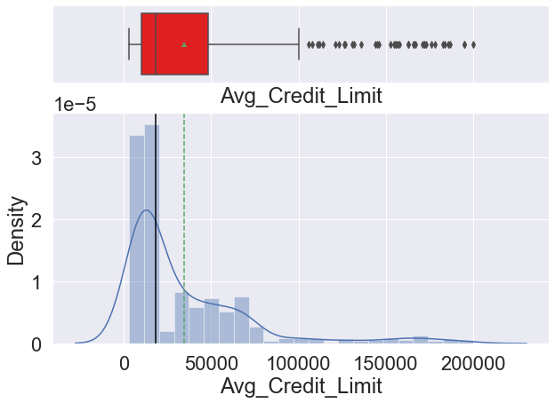

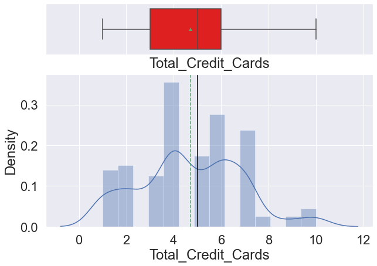

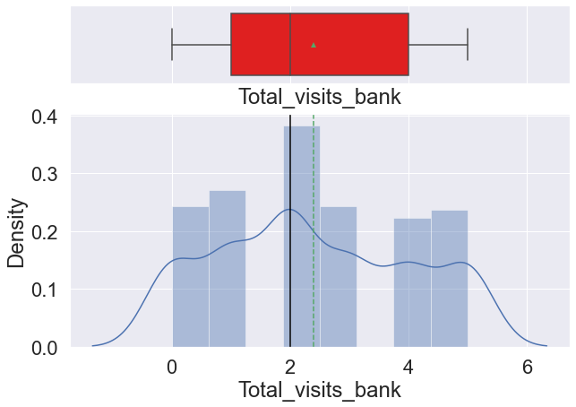

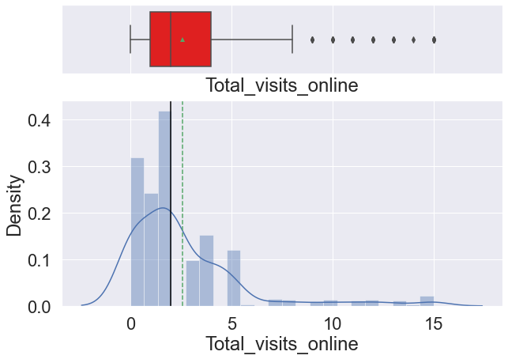

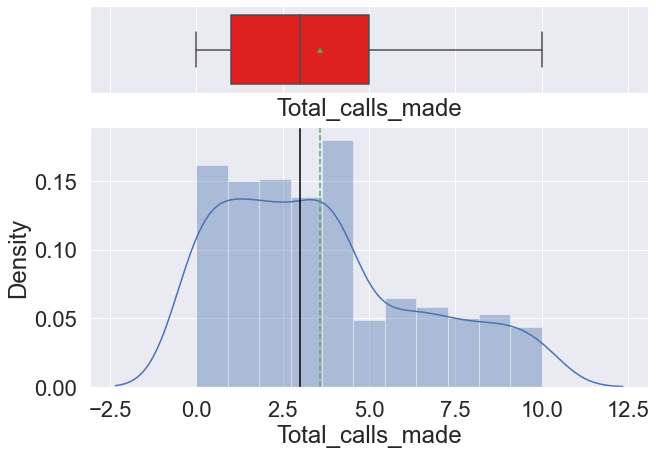

```python
# boxplot and histogram for input numerical variable of all numerical attributes- SL-W2-MLS10
# all_col = df.select_dtypes(include=np.number).columns.tolist() #colums with numeric values
# cont_num.remove("column")  # Will not include 'column' for this portion of the EDA

for i in range(len(eda_num)):                  # loop to call def histogram_boxplot for all columns
    histogram_boxplot(df_eda[eda_num[i]])      # Runs the histogram_boxplot defined function
plt.show()                                     # display plots
```

### Bar Charts for Numerical Category Attributes

#### Barplot with percentage indicators for each category

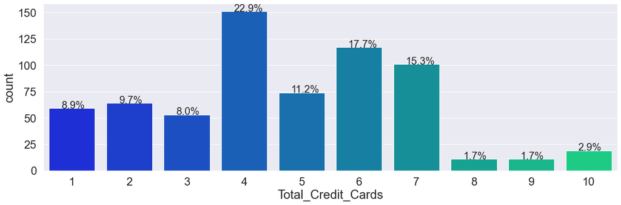

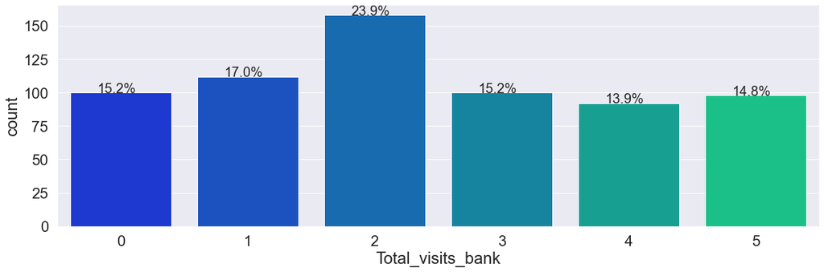

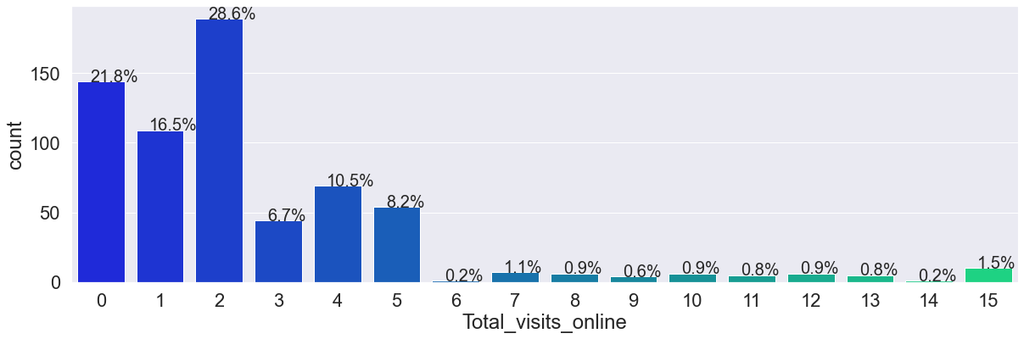

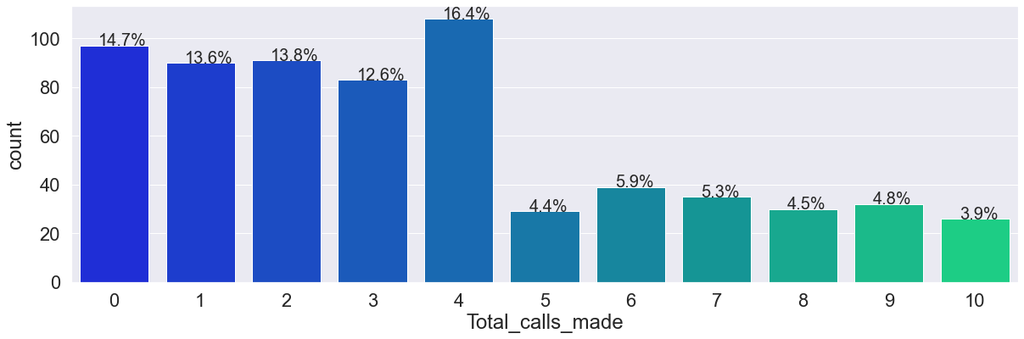

```python
# Generating barplot that indicates percentage for each category - SL-C-W2-MLS 2
for i in cat_num:
    plt.figure(figsize=(20, 6))
    ax = sns.countplot(df_eda[i], palette="winter")
    perc_on_bar(ax, df_eda[i])
```

## Outlier Detection

#### First taking a look at the each attributes min, max, range, quantile values and outlier values for all numerical variables

```python
# Column Range, min, max, quantile and outlier values for all numerical variables
all_col = df_eda.select_dtypes(include=np.number).columns.tolist() # colums with numeric values
for i in range(len(all_col)):
    # Calculating Quantile Values Q1, Q2, Q3 (25%,50%, 75%) and IQR - PF-W3-3.7
    Q1 = round(df_eda[all_col[i]].quantile(q=0.25)) #Q1 below which 25% of data lies-PF-W3-3.14
    Q2 = round(df_eda[all_col[i]].quantile(q=0.50)) #Q2 below which 50% of data lies-PF-W3-3.14
    Q3 = round(df_eda[all_col[i]].quantile(q=0.75)) #Q3 below which 75% of data lies-PF-W3-3.14
    IRQ = round(df_eda[all_col[i]].quantile(0.75) - df[all_col[i]].quantile(0.25),2) #IQR Value

    print(f'- {all_col[i]} Column -')               # f-string display - SL-W2-2.2
    # Range of dataset, min, and max - PF-W3-1.7
    print('\t Range of min./max. values: ',
          round(df[all_col[i]].max() - df[all_col[i]].min(),2)) # Displays Minimum Age within attribute
    print('\t\t\tMin. value: ',df[all_col[i]].min(),)           # Displays Maximum Age within attribute
    print('\t\t\tMax. value: ',df[all_col[i]].max(),)           # Mean function rounded to 1-decimal place
    print('\t\t\tMean value: ',round(df[all_col[i]].mean(),1),) # Displays the Median value of dataset
    print('\t\t      Median value: ',df[all_col[i]].median(),)  # Quantile Values Q1, Q2, Q3 (25%,50%, 75%) and IQR
    print('\t\tQuantile values')
    print('\t\t  Q1 Quantile(25%): ',Q1,)                       # prints Q1
    print('\t\t  Q2 Quantile(50%): ',Q2,)                       # prints Q2
    print('\t\t  Q3 Quantile(75%): ',Q3,)                       # prints Q3
    print('\t    QR Meas. of Dispersion: ',IRQ,)                # prints IRQ

    # Identifying the outliers beyond the whiskers - PF MLS 5
    print('\tOutliers beyond whiskers')
    out_high = Q3+(IRQ*1.5)                                     # calculating outlier beyond the Q3 whisker
    out_low = Q1-(IRQ*1.5)                                      # calculating outlier below the Q1 whisker
    print ('\t  Outliers greater than Q3: ', round(out_high,1)) # prints out_high
    print ('\t     Outliers less than Q1: ',round(out_low,1))   # prints out_high
    print ('\n')                                                # line space to separate columns
```

```
- Avg_Credit_Limit Column -
	 Range of min./max. values:  197000
			Min. value:  3000
			Max. value:  200000
			Mean value:  34574.2
		      Median value:  18000.0
		Quantile values
		  Q1 Quantile(25%):  10000
		  Q2 Quantile(50%):  18000
		  Q3 Quantile(75%):  48000
	    QR Meas. of Dispersion:  38000.0
	Outliers beyond whiskers
	  Outliers greater than Q3:  105000.0
	     Outliers less than Q1:  -47000.0


- Total_Credit_Cards Column -
	 Range of min./max. values:  9
			Min. value:  1
			Max. value:  10
			Mean value:  4.7
		      Median value:  5.0
		Quantile values
		  Q1 Quantile(25%):  3
		  Q2 Quantile(50%):  5
		  Q3 Quantile(75%):  6
	    QR Meas. of Dispersion:  3.0
	Outliers beyond whiskers
	  Outliers greater than Q3:  10.5
	     Outliers less than Q1:  -1.5


- Total_visits_bank Column -
	 Range of min./max. values:  5
			Min. value:  0
			Max. value:  5
			Mean value:  2.4
		      Median value:  2.0
		Quantile values
		  Q1 Quantile(25%):  1
```

[output cut: 23 more lines]

```

- Total_calls_made Column -
	 Range of min./max. values:  10
			Min. value:  0
			Max. value:  10
			Mean value:  3.6
		      Median value:  3.0
		Quantile values
		  Q1 Quantile(25%):  1
		  Q2 Quantile(50%):  3
		  Q3 Quantile(75%):  5
	    QR Meas. of Dispersion:  4.0
	Outliers beyond whiskers
	  Outliers greater than Q3:  11.0
	     Outliers less than Q1:  -5.0
```

**Observations - Outliers**

**Avg_Credit_Limit** - Which has a range of 3k - 200k contains high outliers above the 105k limit, and can be further examined by applying the below boxplot function that highly displays outliers for numerical columns

For the categorical type numerical attributes

- **Total credit cards** - Does not contain either high or low outliers
- **Total visits bank** - Does not contain either high or low outliers
- **Total visits online** - Does contain high outliers based on the IRQ value, but will be considered normal based upon the category distribution
- **Total calls made** - Does not contain either high or low outliers

### Use of Boxplot to Check Outliers

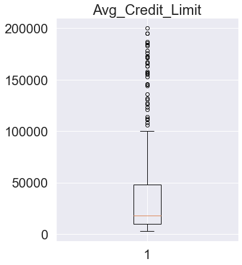

```python
# Plot the boxplots of all non-categorical attributes to check for outliers - SL-W2 - 2.14
plt.figure(figsize=(20, 30))                   # Figure size
for i, variable in enumerate(cont_num):        # for loop to apply to all numeric culumns
    plt.subplot(5, 4, i + 1)                   # subplot settings
    plt.boxplot(df_eda[variable], whis=1.5)    # boxplot function
    plt.tight_layout()                         # layout adjustment
    plt.title(variable)                        # adding title to plots
plt.show()                                     # display plot
```

#### Checking the number of customers with high outlier Average Credit Limits

```python
# isolating attribute observations with high values
df_eda[df_eda["Avg_Credit_Limit"] > 105000]
```

|  | Avg_Credit_Limit | Total_Credit_Cards | Total_visits_bank | Total_visits_online | Total_calls_made |
| --- | --- | --- | --- | --- | --- |
| 612 | 157000 | 9 | 1 | 14 | 1 |
| 614 | 163000 | 8 | 1 | 7 | 1 |
| 615 | 131000 | 9 | 1 | 10 | 1 |
| 617 | 136000 | 8 | 0 | 13 | 0 |
| 618 | 121000 | 7 | 0 | 13 | 2 |
| 619 | 158000 | 7 | 0 | 13 | 0 |
| 620 | 108000 | 10 | 0 | 15 | 1 |
| 621 | 166000 | 9 | 1 | 12 | 2 |
| 622 | 176000 | 10 | 1 | 15 | 2 |
| 623 | 166000 | 10 | 0 | 7 | 0 |
| 624 | 178000 | 7 | 0 | 11 | 0 |
| 626 | 156000 | 9 | 1 | 10 | 2 |
| 627 | 146000 | 10 | 0 | 12 | 1 |
| 629 | 155000 | 8 | 0 | 7 | 2 |
| 630 | 200000 | 10 | 0 | 13 | 0 |
| 631 | 195000 | 8 | 0 | 15 | 0 |
| 632 | 187000 | 7 | 1 | 7 | 0 |
| 633 | 163000 | 7 | 1 | 10 | 1 |
| 634 | 106000 | 8 | 0 | 8 | 1 |
| 635 | 114000 | 10 | 1 | 7 | 2 |
| 636 | 126000 | 10 | 1 | 8 | 0 |
| 637 | 173000 | 9 | 1 | 11 | 0 |
| 638 | 153000 | 8 | 1 | 7 | 1 |
| 639 | 184000 | 7 | 1 | 15 | 2 |
| 640 | 123000 | 8 | 1 | 15 | 2 |
| 641 | 144000 | 10 | 0 | 10 | 2 |
| 644 | 127000 | 10 | 1 | 15 | 1 |
| 645 | 171000 | 10 | 0 | 15 | 0 |
| 646 | 186000 | 7 | 0 | 8 | 1 |
| 647 | 183000 | 9 | 0 | 9 | 2 |
| 648 | 111000 | 8 | 1 | 7 | 0 |
| 649 | 112000 | 10 | 1 | 8 | 1 |
| 650 | 195000 | 10 | 1 | 12 | 2 |
| 651 | 132000 | 9 | 1 | 12 | 2 |
| 652 | 156000 | 8 | 1 | 8 | 0 |
| 654 | 172000 | 10 | 1 | 9 | 1 |
| 657 | 145000 | 8 | 1 | 9 | 1 |
| 658 | 172000 | 10 | 1 | 15 | 0 |
| 659 | 167000 | 9 | 0 | 12 | 2 |

**Observations and Insights - Avg_Credit_Limit Attribute**

- Observations with high outliers are within the indext range of 612 through 659
- Customers in the high outlier range have 7-10 credit cards issued to them by the bank, which may account for the low percentage of customers having 8 or greater credit cards
- Customers in the high outlier range demonstrate a much higher usage of total visits online as compared to visits or calls to the bank

### Outlier Treatment:

- Overall, only two high outliers greater than the whisker were identified for one non-category numerical attribute (Avg_Credit_Limit) and one numerical category attribute (Total_visits_online)
- Looking into the number of customer records for the **Avg_Credit_Limit** outlier group will be considered acceptable, since it is possible to have a high average credit limit depending on the type of banking customer, especially business customers.
- The outliers for Total_visits_online will be considered acceptable since the attribute does contain limited category values within reason.
- As a result, **No Outlier Treatment will be necessary**.

## Bivariate Analysis

Because the unsupervised dataset does not contain a y-dependent variable the use of a 'hue' will not be applied within this analysis

Instead this bivaraite analysis will then be focused on groups and possible peaks contained within the attribute data, and we will take a look at covariance and acorrelation relationships between the different attributes

#### Use of Pairplot Function for Checking Covariances

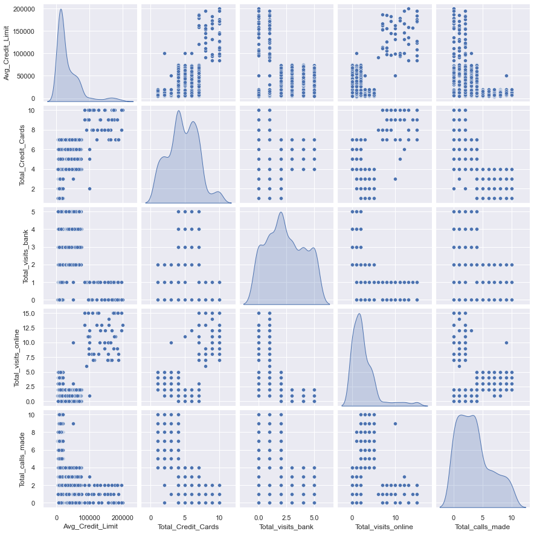

```python
# # Pairplot for checking covariances - Source: PF-W3-3.13 / EDA Univariate and Multivariate Analysis
# # df_eda.cov() # Print a covariance table displaying the of each attribute against every other attribute
# # Using scatter plots for every pair of attributes and histograms along the diagonal
# # Pairplot function with regression bar for initial highlevel analysis of anything standing out in the dataset
sns.pairplot(df_eda,diag_kind="kde",)#  hue="Avg_Credit_Limit") # plots scatter plots with hue
                                     # kind="reg" - "reg" provides regretion line
                                     # "reg" - representation of a linear line that goes through the data
plt.show()
```

**Observations and Insights - Covariance Plots**

Overall, the plots do not provide any direct correlation patterns between attributes, which may be due to four of the five attributes containing category type numerical data

- **Avg_Credit_Limit** - This attribute appears to be right skewed and displays possibly two peaks based on the KDE curve displaying one strong peak and one peak in the outlier region
- **Total credit cards** - Based on the peaks of the KDE curve this attribute displays 3 to a possible 4 groups of credit card holders, based on the two strong peaks, and two minor peaks
- **Total visits bank** - This attibute displays one strong peak, with three small peaks, based on the KDE curve
- **Total visits online** - This attibute displays one strong peak, with only a slight peak in the outlier region of the, based on the KDE curve
- **Total calls made** - This attibute displays two peaks near to one another, based on the KDE curve

### Use of the Covariance Table

```python
# Output of a covariance table displaying the of each attribute against every other attribute
round(df_eda.cov(),2)
```

|  | Avg_Credit_Limit | Total_Credit_Cards | Total_visits_bank | Total_visits_online | Total_calls_made |
| --- | --- | --- | --- | --- | --- |
| Avg_Credit_Limit | 1.415677e+09 | 49662.22 | -6158.95 | 60904.86 | -44670.84 |
| Total_Credit_Cards | 4.966222e+04 | 4.70 | 1.12 | 1.07 | -4.05 |
| Total_visits_bank | -6.158950e+03 | 1.12 | 2.66 | -2.64 | -2.37 |
| Total_visits_online | 6.090486e+04 | 1.07 | -2.64 | 8.62 | 1.07 |
| Total_calls_made | -4.467084e+04 | -4.05 | -2.37 | 1.07 | 8.21 |

**Observations and Insights - Covariance Table**

- Average credit limit displays a positive covariance values with the Total_Credit_Cards and Total_visits_online attributes, which is in line with the Avg_Credit_Limit high outliers that a higher number of credit cards issued to them in addition to displaying a much higher usage of total visits online as compared to visits or calls to the bank, as compared to calls and visits to the bank that were very low for these customers

### Use of General Correlation Heatmap Plot

Next, we will plot a Correlation Heatmap to view relation between attributes

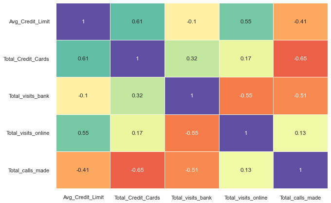

```python
# Plotting Correlation Heatmap to view relation between attributes - SL-W2-2.6
sns.set(rc={'figure.figsize':(10,7)})  # set figure size
sns.heatmap(df_eda.corr(),
            annot=True,
            linewidths=.5,
            center=0,
            cbar=False,
            cmap="Spectral")            # use of heatmap function
plt.show()
```

#### Calculated correlation values with Respect to 'Avg_Credit_Limit'

```python
# Using the correlation funct to calulate values between variables
df_eda.corr()['Avg_Credit_Limit'].sort_values(ascending = False)
```

```
Avg_Credit_Limit       1.000000
Total_Credit_Cards     0.608860
Total_visits_online    0.551385
Total_visits_bank     -0.100312
Total_calls_made      -0.414352
Name: Avg_Credit_Limit, dtype: float64
```

**Observations and Insights - Correlation Heatmap in Relation to "Avg_Credit_Limit"**

The results of the correlation heatmap and the calculated correlation values with respect to the Average credit limit, displays positive correlation values with the Total_Credit_Cards and Total_visits_online attributes, which is inline with the covariance table in that the higher number of credit cards issued to customers is likely to lead to a much higher usage of total visits online as compared to visits or calls to the bank, as compared to calls and visits to the bank that are more common with customers having fewer credit cards

## Bivariate Analysis Plots

In addition to examing the covariarance and coorelation plots and calculations we will exam the relationship between the attributes using boxplots to compare dataset attributes directly against one another

#### Boxplot Observations on "Total_Credit_Cards" vs "Avg_Credit_Limit"

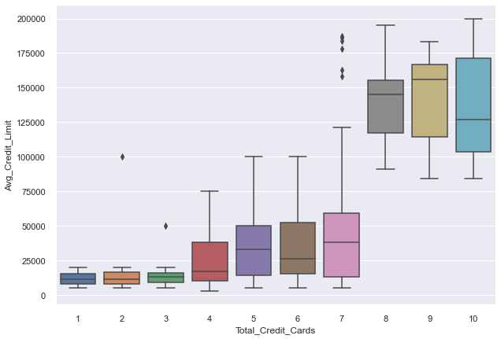

```python
sns.set(rc={"figure.figsize": (10, 7)})
sns.boxplot(x="Total_Credit_Cards", y="Avg_Credit_Limit", data=df_eda, orient="vertical")
```

This boxplot when using the Total_Credit_Cards against the Avg_Credit_Limit, displays strong grouping of 3 clusters based on the number of credit cards a customer owns

#### Boxplot Observations on "Total_visits_online" vs "Avg_Credit_Limit"

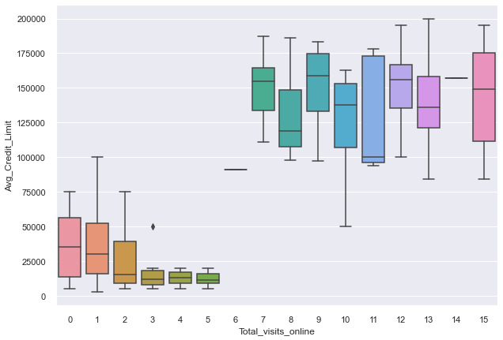

```python
sns.set(rc={"figure.figsize": (10, 7)})
sns.boxplot(x="Total_visits_online", y="Avg_Credit_Limit", data=df_eda, orient="vertical")
```

This boxplot when using the Total_visits_online against the Avg_Credit_Limit displays two strongly separated groups between those customers having 1 to 5 total visits online, as compared to those customers having 6 or more total visits online

#### Boxplot Observations on "Total_visits_bank" vs "Avg_Credit_Limit"

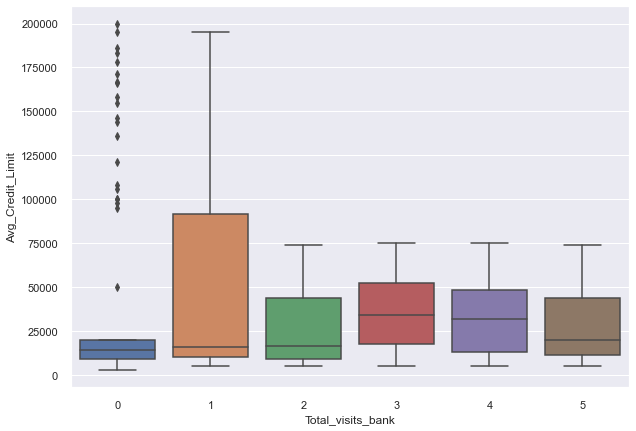

```python
sns.set(rc={"figure.figsize": (10, 7)})
sns.boxplot(x="Total_visits_bank", y="Avg_Credit_Limit", data=df_eda, orient="vertical")
```

This boxplot when using the Total_visits_bank against the Avg_Credit_Limit displays a single group of total visits to the bank dislaying that customers with credit limits below 50k credit limit are likely to have 2 or more visits to the bank while customers with a greater than 50k - 90k credit limit are likely to have only 1 visit to the bank, while customer with credit limits above 90k are not likely to visit the bank

#### Boxplot Observations on "Total_calls_made" vs "Avg_Credit_Limit"

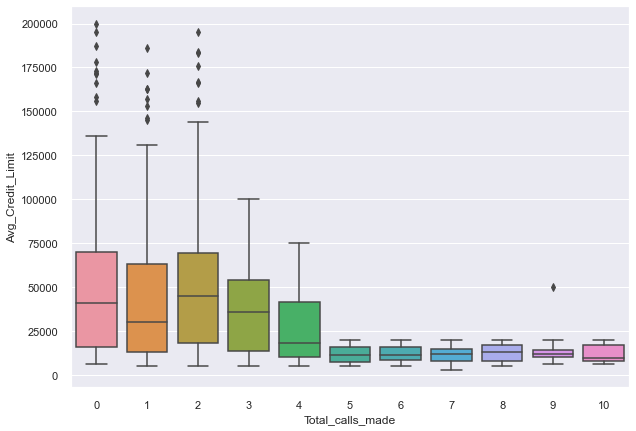

```python
sns.set(rc={"figure.figsize": (10, 7)})
sns.boxplot(x="Total_calls_made", y="Avg_Credit_Limit", data=df_eda, orient="vertical")
```

This boxplot when using the Total_calls_made against the Avg_Credit_Limit displays two groups of total calls made to the bank dislaying that customers with credit limits below 20k credit limit are likely to make 5 or more calls to the bank while customers with a greater than 20k credit limit are more likely to make only 0 to 4 calls to the bank

#### Boxplot Observations on "Total_Credit_Cards" vs "Total_visits_online"

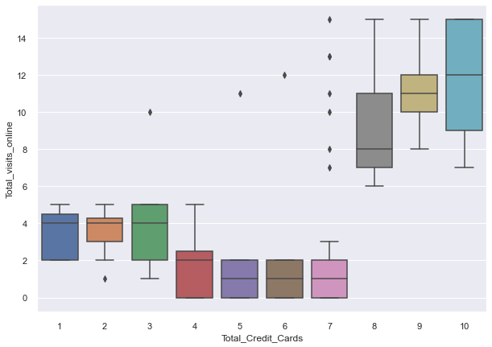

```python
sns.set(rc={"figure.figsize": (10, 7)})
sns.boxplot(x="Total_Credit_Cards", y="Total_visits_online", data=df_eda, orient="vertical")
```

This boxplot when using the Total_Credit_Cards against the Total_visits_online displays three groups of total credit cards in that customers with 1 to 3 credit cards are likely to have 2 to 5 total visits online, while customers with 4 to 7 credit cards are likely to have 0 to 2 total visits online, as compared to customers with 8 or more credit cards are likely to have 7 or more total visits online

#### Boxplot Observations on "Total_Credit_Cards" vs "Total_visits_bank"

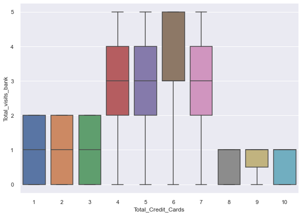

```python
sns.set(rc={"figure.figsize": (10, 7)})
sns.boxplot(x="Total_Credit_Cards", y="Total_visits_bank", data=df_eda, orient="vertical")
```

This boxplot when using the Total_Credit_Cards against the Total_visits_bank displays three separate groups of total credit cards in that customers with 1 to 3 credit cards are likely to have 0 to 2 total visits to the bank, while customers with 4 to 7 credit cards are likely to have 2 or more total visits to the bank, as compared to customers with 8 or more credit cards are likely to have 0 or 1 single visit to the bank

#### Boxplot Observations on "Total_Credit_Cards" vs "Total_calls_made"

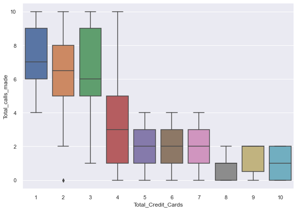

```python
sns.set(rc={"figure.figsize": (10, 7)})
sns.boxplot(x="Total_Credit_Cards", y="Total_calls_made", data=df_eda, orient="vertical")
```

This boxplot when using the Total_Credit_Cards against the Total_calls_made displays three possibly 4 groups of total credit cards in that customers with 1 to 3 credit cards are likely to make 5 or more total calls to the bank, while customers with 4 to 7 credit cards are likely to have 1 to 3 total calls to the bank with the exception that customers having 4 credit cards can have up to 5 total calls to the bank, as compared to customers with 8 or more credit cards are likely to have 0 to 2 total calls to the bank with customers having 8 credit cards are more likely to have 0 or 1 total calls to the bank

**Overall Observation of the Bivariate Analysts - Upgrade the Service Delivery Model**

The overall observation from the bivariate analysis displays strong grouping of observations based on the attributes being compare against. The grouping ranges from 1 - 3, with groups of 3 was more prevalent amount the groupings

The bivariate groupings can provide the banks Operations team the critical information that is needed to upgrade their service delivery model, to ensure that customer queries are resolved faster. Grouping based on the two attributes of Total_Credit_Cards held by a customer and the Avg_Credit_Limit provide the bast way for the marketing team to run personalized campaigns to target new customers as well as upsell to existing customers.

# Data Preparation for Analysis and Feature Engineering

The next step is to conduct data preparation for analysis and feature engineering to get the dataset ready for conducting our analysis

#### We will first make a copy of the dataset to create a analysis/modeling dataset to work with, so that we can to come back and make any changes to our dataset without changing the original data set

```python
# making a copy of the dataset to create a modeling dataset to work with
df_kclust = df.copy()
```

Next, in this case we will take the same attribute group that was used for the EDA and make a copy of it into our cluster analysis set, so that we can work with the five attributes, without dropping or separating the attributes from the Customer_Key attribute in case we later choose to apply a Supervised Technique to the dataset

```python
# copying a data group to a new set
clust_set = eda_num.copy()
```

#### Displaying detailed info of the variables used for clustering

```python
df_kclust[clust_set].info() # Provides detailed info of the data group attributes
```

```
<class 'pandas.core.frame.DataFrame'>
RangeIndex: 660 entries, 0 to 659
Data columns (total 5 columns):
 #   Column               Non-Null Count  Dtype
---  ------               --------------  -----
 0   Avg_Credit_Limit     660 non-null    int64
 1   Total_Credit_Cards   660 non-null    int64
 2   Total_visits_bank    660 non-null    int64
 3   Total_visits_online  660 non-null    int64
 4   Total_calls_made     660 non-null    int64
dtypes: int64(5)
memory usage: 25.9 KB
```

## Feature Engineering

#### Dropping redundant or attributes that will not apply to our analysis or models

Typically we would drop any attributes that will not apply to our predictive models, but due to the small size of this dataset and minimal number of attributes, at this time we will leave the original dataset "as-is", except for the Sl_No attribute, that was dropped initially

```python
# # Dropping redundant or non-applicable attributes from the models
# df_kclust.drop(columns=["attribute1",
#         "attribute2",
#         ], inplace=True)
```

### Missing-Value Treatment

Normally we would impute missing values, remove, or provide some other appropriate missing-value treatment to attribute observations with missing or incorrect values. Since this dataset does not contain any missing or incorrect values, missing-value treatments for this dataset will not be required.

### Scaling the Dataset before Clustering

In an effort to prevent attributes with large scales such as Ave_Credit_Limit, we will normalize the data using Z-score before performing K-means clustering

```python
# scale each column to lose their units and represent no. of std devs & create new table
df_scaled = df_kclust[clust_set].apply(zscore)
```

```python
df_scaled.head()
```

|  | Avg_Credit_Limit | Total_Credit_Cards | Total_visits_bank | Total_visits_online | Total_calls_made |
| --- | --- | --- | --- | --- | --- |
| 0 | 1.740187 | -1.249225 | -0.860451 | -0.547490 | -1.251537 |
| 1 | 0.410293 | -0.787585 | -1.473731 | 2.520519 | 1.891859 |
| 2 | 0.410293 | 1.058973 | -0.860451 | 0.134290 | 0.145528 |
| 3 | -0.121665 | 0.135694 | -0.860451 | -0.547490 | 0.145528 |
| 4 | 1.740187 | 0.597334 | -1.473731 | 3.202298 | -0.203739 |

#### Plotting the kernel density estimate (kde) for each variable in new table

The primary objective here that we are looking for are the kde plots, to tell us the minimum number of clusters we need, based off of the number of peaks in each kde plot

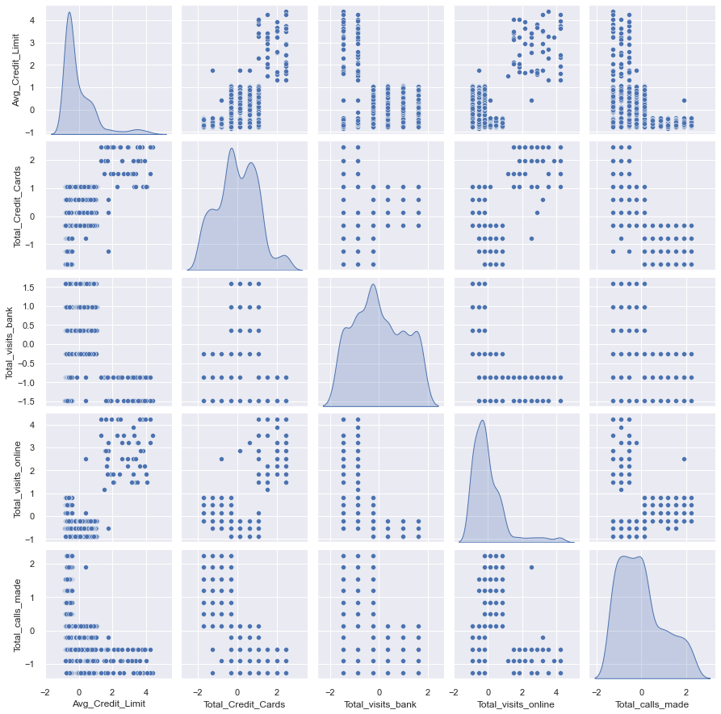

```python
# perform some clustering analysis by grouping problem types together - UL-W1-1.4

# plot(diagonally)the kernel density estimate (kde) for each variable in new table
sns.pairplot(df_scaled,diag_kind = 'kde')
plt.show()
```

**Observations and Insights - Scaled Covariance Plots**

Overall, the plots provide the same correlation patterns between attributes as was displayed in the EDA portion of the dataset analysis

- **Avg_Credit_Limit** - This attribute appears to be right skewed and displays possibly two peaks based on the KDE curve displaying one strong peak and one peak in the outlier region
- **Total credit cards** - Based on the peaks of the KDE curve this attribute displays 3 to a possible 4 groups of credit card holders, based on the two strong peaks, and two minor peaks
- **Total visits bank** - This attibute displays one strong peak, with three small peaks, based on the KDE curve
- **Total visits online** - This attibute displays one strong peak, with only a slight peak in the outlier region of the, based on the KDE curve
- **Total calls made** - This attibute displays two peaks near to one another, based on the KDE curve

## K-Means Clustering - Elbow Curve

Now, we will use K-Means clustering to group data based on their attribute, then plot the output to **visualize the Elbow curve**. First, we need to determine the optimal number of groups. For that we conduct the knee test to see where the knee happens.

```
Number of Clusters: 1 	Average Distortion: 2.0069222262503614
Number of Clusters: 2 	Average Distortion: 1.4571553548514269
Number of Clusters: 3 	Average Distortion: 1.1466276549150365
Number of Clusters: 4 	Average Distortion: 1.0463825294774465
Number of Clusters: 5 	Average Distortion: 0.9908683849620168
Number of Clusters: 6 	Average Distortion: 0.9426729880439931
Number of Clusters: 7 	Average Distortion: 0.9104562946635533
Number of Clusters: 8 	Average Distortion: 0.8900423332311242
```

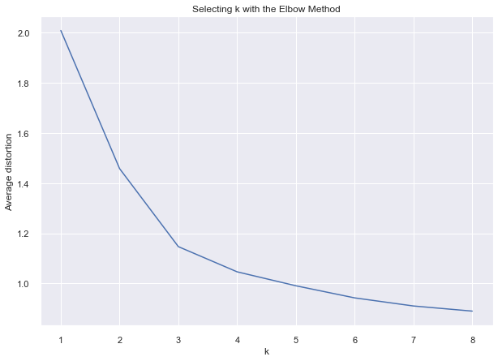

```python
#Finding optimal nnumber of clusters - UL-W1-1.5
from scipy.spatial.distance import cdist  # Takes 2-different sets of points, finds the pairwise dist for each pair
# set of points will be techSuppScaled & model.cluster_centers_ from below
# related to the pdist function, defines pairwise distance between points
clusters=range(1,9)                      # trying clusters in the range of 1 to 10 for different k within the loop
meanDistortions=[]

for k in clusters:
    model=KMeans(n_clusters=k)           # using KMeans for different cluster 1 to 10
    model.fit(df_scaled)                 # uses scaled data from the cell above for the KMeans model
    prediction=model.predict(df_scaled)  # use the KMeans model to predict for each cluster
    distortions=(sum(np.min(cdist(df_scaled, model.cluster_centers_,
                                            'euclidean'), axis=1)) / df_scaled.shape[0])

    meanDistortions.append(distortions)
    print("Number of Clusters:", k, "\tAverage Distortion:", distortions)

    # for each cluster find the
    # model centroids (model.cluster_centers_), and find those distances from each of the points (techSuppScaled),
    # then(np.min)to take the 'euclidean' min. that will give us the distance from every point to every centroid,
    # then sum() those distances and average them out (/ techSuppScaled.shape[0]), and append them as the mean
    # distortion for each k, one at a time

# Plotting the output from above to visualize the Elbow curve
plt.plot(clusters, meanDistortions, 'bx-')
plt.xlabel('k')
plt.ylabel('Average distortion')
plt.title('Selecting k with the Elbow Method')
plt.show()
```

**The appropriate values for k from the elbow curve displays that based on the bends 2, 3, or 4 could be used for k, which coincides with the results of the bivariate analysis**

Next we will check the silhouette scores for the clusters

### Calculating the Silhouette Score

```
For n_clusters = 2, silhouette score is 0.41842496663215445
For n_clusters = 3, silhouette score is 0.5157182558881063
For n_clusters = 4, silhouette score is 0.3556670619372605
For n_clusters = 5, silhouette score is 0.2717470361089752
For n_clusters = 6, silhouette score is 0.25524298453113026
For n_clusters = 7, silhouette score is 0.23441783241674702
For n_clusters = 8, silhouette score is 0.2263145201528689
```

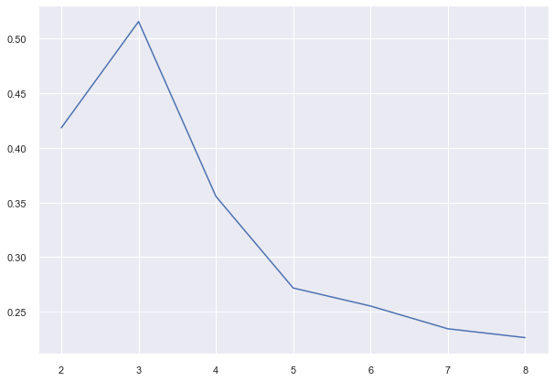

```python
# Calculating the Silhouette Score
sil_score = []
cluster_list = list(range(2, 9))
for n_clusters in cluster_list:
    clusterer = KMeans(n_clusters=n_clusters)
    preds = clusterer.fit_predict((df_scaled))
    # centers = clusterer.cluster_centers_
    score = silhouette_score(df_scaled, preds)
    sil_score.append(score)
    print("For n_clusters = {}, silhouette score is {}".format(n_clusters, score))

plt.plot(cluster_list, sil_score)
```

**Based on the silhouette scores, 3 appears to be higher than that for 2 or 4. So, we will choose 3 as value of k**

### Finding optimal number of clusters based upon silhouette coefficients

We will now look at the silhouette coefficients against the y-axis for K using 5 clusters

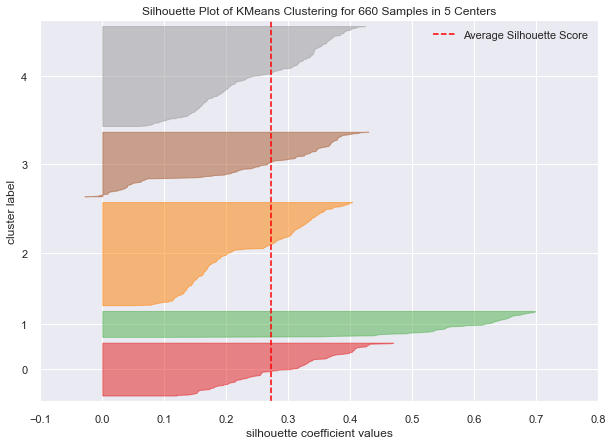

```python
# finding optimal no. of clusters with silhouette coefficients
visualizer = SilhouetteVisualizer(KMeans(5, random_state=1))
visualizer.fit(df_scaled)
visualizer.show()
```

## Applying K-means Clustering

Based on the above plot and silhouette coefficients, we will use k = 3 and run a new (KMeans) model

```python
# running a KMeans model, using K=3 - UL-W1-1.5
k3_model=KMeans(n_clusters=3, random_state=1) # KMeans model
k3_model.fit(df_scaled)                       # using scaled data to fit the model
k3prediction=k3_model.predict(df_scaled)      # then use the model to predict

#Append the prediction to a new attribute within the origional table
df_kclust["k=3 Group"] = k3prediction
#Append the prediction to a new attribute within the new table
df_scaled["k=3 Group"] = k3prediction         # to use the boxplot later with same y-axis

print("Groups Assigned : \n")

# viewing a random sample of the dataset
df_kclust.sample(n=10, random_state=1)           # original table now showing new column
```

```
Groups Assigned :
```

|  | Customer_Key | Avg_Credit_Limit | Total_Credit_Cards | Total_visits_bank | Total_visits_online | Total_calls_made | k=3 Group |
| --- | --- | --- | --- | --- | --- | --- | --- |
| 547 | 38125 | 26000 | 4 | 5 | 2 | 4 | 1 |
| 353 | 94437 | 9000 | 5 | 4 | 1 | 3 | 1 |
| 499 | 65825 | 68000 | 6 | 4 | 2 | 2 | 1 |
| 173 | 38410 | 9000 | 2 | 1 | 5 | 8 | 0 |
| 241 | 81878 | 10000 | 4 | 5 | 1 | 3 | 1 |
| 341 | 70779 | 18000 | 4 | 3 | 2 | 0 | 1 |
| 647 | 79953 | 183000 | 9 | 0 | 9 | 2 | 2 |
| 218 | 28208 | 19000 | 3 | 1 | 5 | 7 | 0 |
| 120 | 16577 | 10000 | 4 | 2 | 4 | 6 | 0 |
| 134 | 31256 | 13000 | 4 | 1 | 5 | 7 | 0 |

**Observations - K = 3 Clustering**

From the above random sample output it is displayed that the grouping does not appear to be based on Avg_Credit_Limit, though the third (Group 2) does have a high Avg_Credit_Limit entry values. It can be noticed that lower Avg_Credit_Limit entry values share the same values in Group 0 and 1, to include the same Total_Credit_Cards values.

Based on the sample, these Groupings appear to be based on difference between the Total_visits_bank atribute and the Total_visits_online and Total_calls_made for these three sets of attributes.

```python
# applying to scaled dataset
scaled_clust = df_scaled.groupby(['k=3 Group'])  # now grouping by 'group'
round(scaled_clust.mean(), 2)                    # taking the average of each column
```

| k=3 Group | Avg_Credit_Limit | Total_Credit_Cards | Total_visits_bank | Total_visits_online | Total_calls_made |
| --- | --- | --- | --- | --- | --- |
| 0 | -0.60 | -1.06 | -0.90 | 0.32 | 1.15 |
| 1 | -0.02 | 0.37 | 0.67 | -0.55 | -0.55 |
| 2 | 2.83 | 1.86 | -1.11 | 2.83 | -0.87 |

#### Using the boxplot to display each scaled attribute separately

```
array([[<AxesSubplot:title={'center':'Avg_Credit_Limit'}, xlabel='[k=3 Group]'>,
        <AxesSubplot:title={'center':'Total_Credit_Cards'}, xlabel='[k=3 Group]'>,
        <AxesSubplot:title={'center':'Total_calls_made'}, xlabel='[k=3 Group]'>,
        <AxesSubplot:title={'center':'Total_visits_bank'}, xlabel='[k=3 Group]'>],
       [<AxesSubplot:title={'center':'Total_visits_online'}, xlabel='[k=3 Group]'>,
        <AxesSubplot:>, <AxesSubplot:>, <AxesSubplot:>]], dtype=object)
```

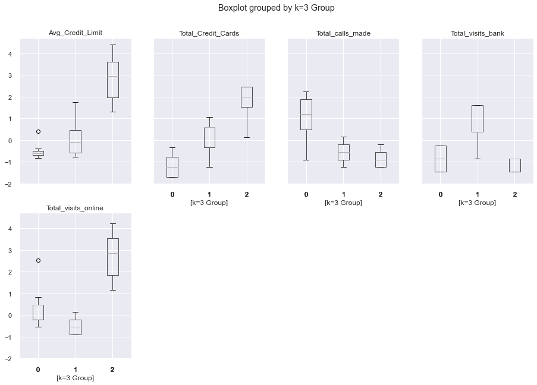

```python
df_scaled.boxplot(by='k=3 Group', layout = (2,4),figsize=(15,10))
```

**Boxplots Observations**

The boxplots provide overall similar results with the boxplots that were displayed in the bivaraite analysis, in showing some sharp separations between some of the groups depending on the attribute.

Next we will add the cluster labels back into the original dataframe

#### Adding K-means Cluster Labels to the original dataframe

```python
# we will use k3_model so we will not have to re-run KMeans again
# kmeans = KMeans(n_clusters=3, random_state=0)
# kmeans.fit(df_scaled)
```

```python
# adding k-means cluster labels to the original dataframe
df_kclust["K_means_Clusters"] = k3_model.labels_
```

## Cluster Profiling

Next, we will perform cluster profiling to check if the cluster profiles are meaningful and have variability, based on the knowledge that we have with regard to the dataset information that we obtained from the EDA

```python
# create a new dataframe based on the mean of the attributes within each cluster
kcluster_profile = df_kclust.groupby("K_means_Clusters").mean()
```

```python
# add counts of observations within each cluster
kcluster_profile["count_in_each_segment"] = (
    df_kclust.groupby("K_means_Clusters")["Avg_Credit_Limit"].count().values)
```

```python
# the Avg_Credit_Limit in each cluster
for cl in df_kclust["K_means_Clusters"].unique():
    print("The", df_kclust[df_kclust["K_means_Clusters"] == cl]["Avg_Credit_Limit"].nunique(),
        "Avg_Credit_Limit", cl, "are:",)
    print(df_kclust[df_kclust["K_means_Clusters"] == cl]["Avg_Credit_Limit"].unique())
    print("-" * 100, "\n")
```

```
The 67 Avg_Credit_Limit 1 are:
[100000  50000  30000  10000   8000  17000  19000  20000  13000  16000
  12000   5000   7000  11000   9000  18000   6000  15000  14000  73000
  49000  67000  61000  75000  48000  56000  72000  70000  51000  69000
  40000  44000  31000  37000  65000  46000  74000  58000  39000  52000
  33000  47000  71000  41000  59000  64000  45000  54000  66000  27000
  43000  36000  25000  57000  26000  38000  35000  34000  28000  63000
  29000  68000  42000  62000  32000  60000  55000]
----------------------------------------------------------------------------------------------------

The 18 Avg_Credit_Limit 0 are:
[50000 20000 15000  5000  3000 10000 13000 11000  9000  6000  8000 19000
 16000 18000 17000 14000 12000  7000]
----------------------------------------------------------------------------------------------------

The 43 Avg_Credit_Limit 2 are:
[100000 157000  94000 163000 131000  96000 136000 121000 158000 108000
 166000 176000 178000  91000 156000 146000  84000 155000 200000 195000
 187000 106000 114000 126000 173000 153000 184000 123000 144000  97000
  98000 127000 171000 186000 183000 111000 112000 132000  95000 172000
  99000 145000 167000]
----------------------------------------------------------------------------------------------------
```

```python
# displaying K-means cluster profiles in the original dataframe based on means
kcluster_profile.style.highlight_max(color="lightgreen", axis=0)
```

| K_means_Clusters | Customer_Key | Avg_Credit_Limit | Total_Credit_Cards | Total_visits_bank | Total_visits_online | Total_calls_made | k=3 Group | count_in_each_segment |
| --- | --- | --- | --- | --- | --- | --- | --- | --- |
| 0 | 55239.830357 | 12174.107143 | 2.410714 | 0.933036 | 3.553571 | 6.870536 | 0.000000 | 224 |
| 1 | 54881.329016 | 33782.383420 | 5.515544 | 3.489637 | 0.981865 | 2.000000 | 1.000000 | 386 |
| 2 | 56708.760000 | 141040.000000 | 8.740000 | 0.600000 | 10.900000 | 1.080000 | 2.000000 | 50 |

**Observation - Original dataframe with new cluster attributes**

Displaying K-means cluster profiles in the original dataframe displays the highest mean values for each attribute between the different clusters within the dataframe. One will notice that the second kmeans cluster (1) contains the highest number of observations, while the third kmeans cluster (2) contains the least amount of observations, which is in line with the those customers with high Avg_Credit_Limit amounts

#### Comparing scaled vs numerical variable boxplots

[figure not shown]

```python
# Boxplot of Scaled Numerical Variables for Each Cluster
fig, axes = plt.subplots(1, 3, figsize=(16, 6))
fig.suptitle("Boxplot of Scaled Numerical Variables for Each K-Means Cluster")
counter = 0
for ii in range(3):
    sns.boxplot(ax=axes[ii], y=df_kclust[clust_set[counter]], x=df_kclust["K_means_Clusters"])
    counter = counter + 1

fig.tight_layout(pad=2.0)
```

**Observations - Comparing scaled vs numerical variable boxplots**

- As seem by the comparisons of unscaled verses scaled data, when creating plots or graphs, both the scaled data in "boxplot grouped by=k=3 Group" and unscaled data plot above, provide similar visual results
- The original dataframe with the added K-means labels demonstrate that the boxplots clustering provide overall similar results with the boxplots that were displayed (above) using the scaled dataframe, in them both showing some sharp separations between some of the groups depending on the attribute

## Applying Hierarchical Clustering

Next, we will apply Hierarchical clustering with different linkage methods to be able to compare the result with K-means Clustering

We will first make a copy of the original dataset to create a analysis/modeling dataset to work with for conducting Hierarchical clustering, so that we can to come back and make any changes to our dataset without changing the original data set

```python
# making a copy of the dataset to create a modeling dataset to work with
df_hclust = df.copy()
```

We will then scale the data before we proceed to cluster it.

To make a fair comparision between the two clustering methods, we will normalize the data again using the Z-score before performing Hierarchical clustering

#### Scaling the Dataset before Clustering

```python
# scale each column to lose their units and represent no. of std devs & create new table
df_hscaled = df_hclust[clust_set].apply(zscore) # scaling the dataset
df_hscaledbu = df_hscaled.copy()                # creating a backup of the scaled dataset
df_hscaled.sample(n=5, random_state=1)          # displaying a sample of the observations
```

|  | Avg_Credit_Limit | Total_Credit_Cards | Total_visits_bank | Total_visits_online | Total_calls_made |
| --- | --- | --- | --- | --- | --- |
| 547 | -0.228057 | -0.325946 | 1.592670 | -0.20660 | 0.145528 |
| 353 | -0.680221 | 0.135694 | 0.979390 | -0.54749 | -0.203739 |
| 499 | 0.889054 | 0.597334 | 0.979390 | -0.20660 | -0.553005 |
| 173 | -0.680221 | -1.249225 | -0.860451 | 0.81607 | 1.542593 |
| 241 | -0.653623 | -0.325946 | 1.592670 | -0.54749 | -0.203739 |

## Applying Hierarchical Clustering

We will then apply Hierarchical clustering with different distance metrics and linkage methods, then calculate the Cophenetic correlation for each combination

```python
# Applying Hierarchical Clustering - UL-W2-MLS 2
# list of distance metrics
distance_metrics = ["euclidean", "chebyshev", "mahalanobis", "cityblock"]

# list of linkage methods
linkage_methods = ["single", "complete", "average", "weighted"]

high_cophenet_corr = 0
high_dm_lm = [0, 0]

for dm in distance_metrics:
    for lm in linkage_methods:
        Z = linkage(df_hscaled, metric=dm, method=lm)
        c, coph_dists = cophenet(Z, pdist(df_hscaled))
        print("Cophenetic correlation for {} distance and {} linkage is {}.".format(
                dm.capitalize(), lm, c))
        if high_cophenet_corr < c:
            high_cophenet_corr = c
            high_dm_lm[0] = dm
            high_dm_lm[1] = lm
```

```
Cophenetic correlation for Euclidean distance and single linkage is 0.7391220243806552.
Cophenetic correlation for Euclidean distance and complete linkage is 0.8599730607972423.
Cophenetic correlation for Euclidean distance and average linkage is 0.8977080867389372.
Cophenetic correlation for Euclidean distance and weighted linkage is 0.8861746814895477.
Cophenetic correlation for Chebyshev distance and single linkage is 0.7382354769296767.
Cophenetic correlation for Chebyshev distance and complete linkage is 0.8533474836336782.
Cophenetic correlation for Chebyshev distance and average linkage is 0.8974159511838106.
Cophenetic correlation for Chebyshev distance and weighted linkage is 0.8913624010768603.
Cophenetic correlation for Mahalanobis distance and single linkage is 0.7058064784553606.
Cophenetic correlation for Mahalanobis distance and complete linkage is 0.6663534463875361.
Cophenetic correlation for Mahalanobis distance and average linkage is 0.8326994115042136.
Cophenetic correlation for Mahalanobis distance and weighted linkage is 0.7805990615142518.
Cophenetic correlation for Cityblock distance and single linkage is 0.7252379350252723.
Cophenetic correlation for Cityblock distance and complete linkage is 0.8731477899179829.
Cophenetic correlation for Cityblock distance and average linkage is 0.896329431104133.
Cophenetic correlation for Cityblock distance and weighted linkage is 0.8825520731498188.
```

```python
# printing the combination of distance metric and linkage method with the highest cophenetic correlation
print("Highest cophenetic correlation is {}, obtained with {} linkage.".format(
        high_cophenet_corr, high_dm_lm[1]))
```

```
Highest cophenetic correlation is 0.8977080867389372, obtained with average linkage.
```

### Plotting the Dendrograms for each linkage method

Next we will plot the dendrograms for the different linkage methods

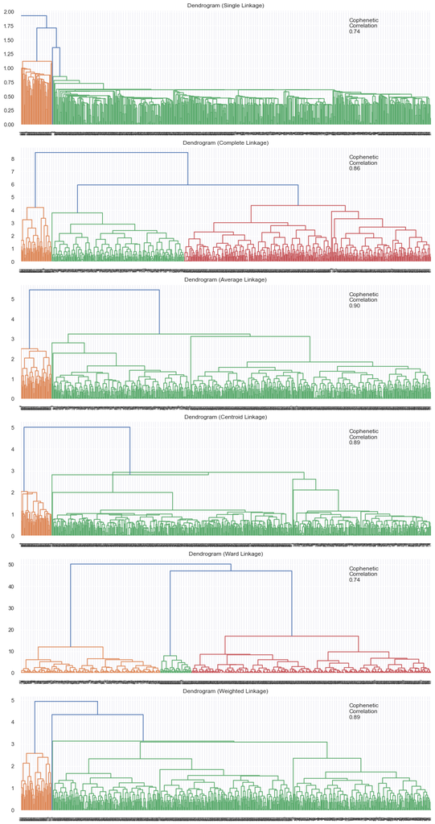

```python
# plotting the dendrograms for the different linkage methods
# list of linkage methods
linkage_methods = ["single", "complete", "average", "centroid", "ward", "weighted"]

# lists to save results of cophenetic correlation calculation
compare_cols = ["Linkage", "Cophenetic Coefficient"]

# to create a subplot image
fig, axs = plt.subplots(len(linkage_methods), 1, figsize=(15, 30))

# We will enumerate through the list of linkage methods above
# For each linkage method, we will plot the dendrogram and calculate the cophenetic correlation
for i, method in enumerate(linkage_methods):
    Z = linkage(df_hscaled, metric="euclidean", method=method)

    dendrogram(Z, ax=axs[i])
    axs[i].set_title(f"Dendrogram ({method.capitalize()} Linkage)")

    coph_corr, coph_dist = cophenet(Z, pdist(df_hscaled))
    axs[i].annotate(
        f"Cophenetic\nCorrelation\n{coph_corr:0.2f}",
        (0.80, 0.80),
        xycoords="axes fraction",)
```

**Observation**

Based on the above Dendrogram for Average Linkage is associated with the highest Cophenetic Correlation value of 0.90, and appears to be associated with 4 clusters

As a result, will will build our model based on this Dendrogram

### Building the Hierarchical Model Using 4 Clusters

```python
# building the Hierarchical model using Agglomerative Clustering
HCmodel = AgglomerativeClustering(n_clusters=4, affinity="euclidean", linkage="average")
HCmodel.fit(df_hscaled)           # Fiting the model
```

```
AgglomerativeClustering(linkage='average', n_clusters=4)
```

```python
# applying labels to the dataset
df_hscaled["HC_Clusters"] = HCmodel.labels_
df_hclust["HC_Clusters"] = HCmodel.labels_
```

```python
df_hclust.head()  # displaying the first five observations
```

|  | Customer_Key | Avg_Credit_Limit | Total_Credit_Cards | Total_visits_bank | Total_visits_online | Total_calls_made | HC_Clusters |
| --- | --- | --- | --- | --- | --- | --- | --- |
| 0 | 87073 | 100000 | 2 | 1 | 1 | 0 | 3 |
| 1 | 38414 | 50000 | 3 | 0 | 10 | 9 | 0 |
| 2 | 17341 | 50000 | 7 | 1 | 3 | 4 | 2 |
| 3 | 40496 | 30000 | 5 | 1 | 1 | 4 | 2 |
| 4 | 47437 | 100000 | 6 | 0 | 12 | 3 | 1 |

## Cluster Profiling

We will now perform cluster profiling on the Hierarchical Clustering to check if the cluster profiles are meaningful and have variability, based on the knowledge that we have with regard to the dataset information that we obtained from the EDA

```python
# create a new dataframe based on the mean of the attributes within each Hierarchical cluster
hcluster_profile = df_hclust.groupby("HC_Clusters").mean()
```

```python
# add counts of observations within each cluster
hcluster_profile["count_in_each_segments"] = (
    df_hclust.groupby("HC_Clusters")["Avg_Credit_Limit"].count().values)
```

```python
# let's see the names of the countries in each cluster grouped
for cl in df_hclust["HC_Clusters"].unique():
    print("The", df_hclust[df_hclust["HC_Clusters"] == cl]["Avg_Credit_Limit"].nunique(),
        "Avg_Credit_Limit in cluster", cl, "are:",)
    print(df_hclust[df_hclust["HC_Clusters"] == cl]["Avg_Credit_Limit"].unique())
    print("-" * 100, "\n")
```

```
The 1 Avg_Credit_Limit in cluster 3 are:
[100000]
----------------------------------------------------------------------------------------------------

The 18 Avg_Credit_Limit in cluster 0 are:
[50000 20000 15000  5000  3000 10000 13000 11000  9000  6000  8000 19000
 16000 18000 17000 14000 12000  7000]
----------------------------------------------------------------------------------------------------

The 66 Avg_Credit_Limit in cluster 2 are:
[50000 30000 10000  8000 17000 19000 20000 13000 16000 12000  5000  7000
 11000  9000 18000  6000 15000 14000 73000 49000 67000 61000 75000 48000
 56000 72000 70000 51000 69000 40000 44000 31000 37000 65000 46000 74000
 58000 39000 52000 33000 47000 71000 41000 59000 64000 45000 54000 66000
 27000 43000 36000 25000 57000 26000 38000 35000 34000 28000 63000 29000
 68000 42000 62000 32000 60000 55000]
----------------------------------------------------------------------------------------------------

The 43 Avg_Credit_Limit in cluster 1 are:
[100000 157000  94000 163000 131000  96000 136000 121000 158000 108000
 166000 176000 178000  91000 156000 146000  84000 155000 200000 195000
 187000 106000 114000 126000 173000 153000 184000 123000 144000  97000
  98000 127000 171000 186000 183000 111000 112000 132000  95000 172000
  99000 145000 167000]
----------------------------------------------------------------------------------------------------
```

**Observations**

Based on the above observation, using 4 clusters caused us to end up with with one cluster with only a single observation.

As a result, we will re-run the building the Hierarchical model, but this time we will use 3 clusters

### Re-Building the Hierarchical Model Using 3 Clusters

```python
# to prevent data leakage, pulling new copies of the dataset needed
df_hclust3 = df.copy()
df_hscaled3 = df_hscaledbu.copy()
```

```python
# building the Hierarchical model using Agglomerative Clustering
HC3model = AgglomerativeClustering(n_clusters=3, affinity="euclidean", linkage="average")
HC3model.fit(df_hscaled3)
```

```
AgglomerativeClustering(linkage='average', n_clusters=3)
```

```python
# applying labels
df_hscaled3["HC_Clusters"] = HC3model.labels_
df_hclust3["HC_Clusters"] = HC3model.labels_
df_hclust3.head()      # displaying the first five observayions
```

|  | Customer_Key | Avg_Credit_Limit | Total_Credit_Cards | Total_visits_bank | Total_visits_online | Total_calls_made | HC_Clusters |
| --- | --- | --- | --- | --- | --- | --- | --- |
| 0 | 87073 | 100000 | 2 | 1 | 1 | 0 | 0 |
| 1 | 38414 | 50000 | 3 | 0 | 10 | 9 | 2 |
| 2 | 17341 | 50000 | 7 | 1 | 3 | 4 | 0 |
| 3 | 40496 | 30000 | 5 | 1 | 1 | 4 | 0 |
| 4 | 47437 | 100000 | 6 | 0 | 12 | 3 | 1 |

## Cluster Profiling of 3 Hierarchical Cluster

We will now re-perform cluster profiling on the 3 Hierarchical Clusters to check if the cluster profiles are meaningful and have variability, based on the knowledge that we have with regard to the dataset information that we obtained from the EDA

```python
# create a new dataframe based on the mean of the attributes within each Hierarchical cluster
hcluster3_profile = df_hclust3.groupby("HC_Clusters").mean()
```

```python
# add counts of observations within each cluster
hcluster3_profile["count_in_each_segments"] = (
    df_hclust3.groupby("HC_Clusters")["Avg_Credit_Limit"].count().values)
```

```python
# each cluster grouped based on mean values
for cl in df_hclust3["HC_Clusters"].unique():
    print("The", df_hclust3[df_hclust3["HC_Clusters"] == cl]["Avg_Credit_Limit"].nunique(),
        "Avg_Credit_Limit in cluster", cl, "are:",)
    print(df_hclust3[df_hclust3["HC_Clusters"] == cl]["Avg_Credit_Limit"].unique())
    print("-" * 100, "\n")
```

```
The 67 Avg_Credit_Limit in cluster 0 are:
[100000  50000  30000  10000   8000  17000  19000  20000  13000  16000
  12000   5000   7000  11000   9000  18000   6000  15000  14000  73000
  49000  67000  61000  75000  48000  56000  72000  70000  51000  69000
  40000  44000  31000  37000  65000  46000  74000  58000  39000  52000
  33000  47000  71000  41000  59000  64000  45000  54000  66000  27000
  43000  36000  25000  57000  26000  38000  35000  34000  28000  63000
  29000  68000  42000  62000  32000  60000  55000]
----------------------------------------------------------------------------------------------------

The 18 Avg_Credit_Limit in cluster 2 are:
[50000 20000 15000  5000  3000 10000 13000 11000  9000  6000  8000 19000
 16000 18000 17000 14000 12000  7000]
----------------------------------------------------------------------------------------------------

The 43 Avg_Credit_Limit in cluster 1 are:
[100000 157000  94000 163000 131000  96000 136000 121000 158000 108000
 166000 176000 178000  91000 156000 146000  84000 155000 200000 195000
 187000 106000 114000 126000 173000 153000 184000 123000 144000  97000
  98000 127000 171000 186000 183000 111000 112000 132000  95000 172000
  99000 145000 167000]
----------------------------------------------------------------------------------------------------
```

**Observation**

The contants of the Hierarchical Clustering appear to be very similar to the contents of the K-means clusters

#### Displaying the Hierarchical cluster profile in the original dataframe based on mean calculation

```python
# displaying the Hierarchical cluster profile in the original dataframe based on means
hcluster3_profile.style.highlight_max(color="lightgreen", axis=0)
```

| HC_Clusters | Customer_Key | Avg_Credit_Limit | Total_Credit_Cards | Total_visits_bank | Total_visits_online | Total_calls_made | count_in_each_segments |
| --- | --- | --- | --- | --- | --- | --- | --- |
| 0 | 54925.966408 | 33713.178295 | 5.511628 | 3.485788 | 0.984496 | 2.005168 | 387 |
| 1 | 56708.760000 | 141040.000000 | 8.740000 | 0.600000 | 10.900000 | 1.080000 | 50 |
| 2 | 55163.973094 | 12197.309417 | 2.403587 | 0.928251 | 3.560538 | 6.883408 | 223 |

**Observation**

The contants of the Hierarchical Clustering appear to be very similar to the contents of the K-means clusters

Next, we will plot the scaled numerical values to be compared against the original numerical values

#### Plotting the scaled and normal numerical values

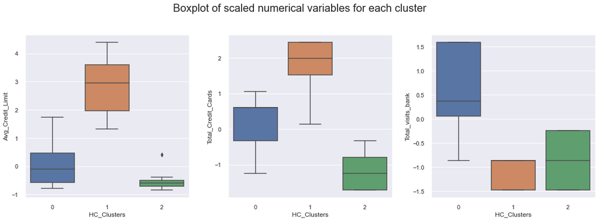

```python
fig, axes = plt.subplots(1, 3, figsize=(16, 6))
fig.suptitle("Boxplot of scaled numerical variables for each cluster", fontsize=20)
counter = 0
for ii in range(3):
    sns.boxplot(ax=axes[ii], y=df_hscaled3[clust_set[counter]], x=df_hscaled3["HC_Clusters"])
    counter = counter + 1

fig.tight_layout(pad=2.0)
```

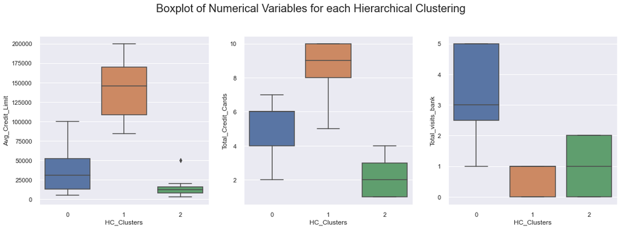

```python
fig, axes = plt.subplots(1, 3, figsize=(16, 6))
fig.suptitle("Boxplot of Numerical Variables for each Hierarchical Clustering", fontsize=20)
counter = 0
for ii in range(3):
    sns.boxplot(ax=axes[ii], y=df_hclust3[clust_set[counter]], x=df_hclust3["HC_Clusters"])
    counter = counter + 1

fig.tight_layout(pad=2.0)
```

**Observations - Plotting Scaled vs Unscaled Numerical Values**

- The Hierarchical Clustering boxplots are similar to the K-means clustering, but with the groups of assigned to different clusters
- As seem by the comparisons of unscaled verses scaled data, when creating plots or graphs, both the scaled data in "boxplot grouped by=k=3 Group" and unscaled data plot above, provide similar visual results
- The original dataframe with the added K-means labels demonstrate that the boxplots clustering provide overall similar results with the boxplots that were displayed (above) using the scaled dataframe, in them both showing some sharp separations between some of the groups depending on the attribute

## Comparison of clusters obtained from K-means and Hierarchical clustering techniques

Overall results between the two methods provided very similar results, with only 1 observation difference Each method provided trade-offs to the other method

## Business Recommendations

- AllLife Bank should make a strong effort to expand marketing based on the Average Credit Limits and Total Credit Cards held by their customer base
- Based upon the Total Credit Cards attribute the total credit cards held by a customer and the Avg_Credit_Limit provide the bast way for the marketing team to run personalized campaigns to target new customers as well as upsell to existing customers
- The bivariate groupings can provide the banks Operations team the critical information that is needed to upgrade their service delivery model, to ensure that customer queries are resolved faster.

**Based upon the EDA Insight**:

- The overall observation from the bivariate analysis displays strong grouping of observations based on the attributes being compare against. The grouping ranges from 1 - 3, with groups of 3 was more prevalent amount the groupings
- When using the Total_Credit_Cards against the Avg_Credit_Limit, displays strong grouping of 3 clusters based on the number of credit cards a customer owns
- When using the Total_visits_bank against the Avg_Credit_Limit displays a single group of total visits to the bank dislaying that customers with credit limits below 50k credit limit are likely to have 2 or more visits to the bank while customers with a greater than 50k - 90k credit limit are likely to have only 1 visit to the bank, while customer with credit limits above 90k are not likely to visit the bank
- When using the Total_calls_made against the Avg_Credit_Limit displays two groups of total calls made to the bank dislaying that customers with credit limits below 20k credit limit are likely to make 5 or more calls to the bank while customers with a greater than 20k credit limit are more likely to make only 0 to 4 calls to the bank
- When using the Total_Credit_Cards against the Total_visits_online displays three groups of total credit cards in that customers with 1 to 3 credit cards are likely to have 2 to 5 total visits online, while customers with 4 to 7 credit cards are likely to have 0 to 2 total visits online, as compared to customers with 8 or more credit cards are likely to have 7 or more total visits online
- When using the Total_Credit_Cards against the Total_visits_bank displays three separate groups of total credit cards in that customers with 1 to 3 credit cards are likely to have 0 to 2 total visits to the bank, while customers with 4 to 7 credit cards are likely to have 2 or more total visits to the bank, as compared to customers with 8 or more credit cards are likely to have 0 or 1 single visit to the bank
- when using the Total_Credit_Cards against the Total_calls_made displays three possibly 4 groups of total credit cards in that customers with 1 to 3 credit cards are likely to make 5 or more total calls to the bank, while customers with 4 to 7 credit cards are likely to have 1 to 3 total calls to the bank with the exception that customers having 4 credit cards can have up to 5 total calls to the bank, as compared to customers with 8 or more credit cards are likely to have 0 to 2 total calls to the bank with customers having 8 credit cards are more likely to have 0 or 1 total calls to the bank

# Conclusion

- K-means Clusters had the best performance over the Hierarchical Clustering technique
- Both techniques supported the findings within the EDA Univariate and Bivariate analysis portion of this analysis